# USUniversities.Rmd

Varun Parameswaran, Stanley Urbanek

October 2, 2015

# University Demographics and Debt by State

### Introduction

We wished to know about the demographics of universities around the United States. We located a data set that was a list of ~8000 US universities with demographic make up, SAT Scores, initial income post graudation, and percentage taking a financial loan. We will run 3 experiments to draw conclusions about US Universities.

We operated on a CSV file, uploaded to the Oracle database, in R. Below, we initialize our system.

```r
source("../01 Data/Initialize.R", echo = TRUE)
```

[output not shown]

```
##
## > require(extrafont)
```

[output not shown]

[output not shown]

```
##
## > require(ggthemes)
```

[output not shown]

```
##
## > require(grid)
```

```
##
## > require(jsonlite)
```

[output not shown]

```
##
## > require(RCurl)
```

```
##
## > require(reshape2)
```

```
##
## > require(rstudioapi)
```

[output not shown]

```
##
## > require(tidyr)
```

[output not shown]

Here is our R_ETL file’s operations, which allow us to “clean” the data in RStudio and export it to SQL.

```r
source("../01 Data/R_ETL.R", echo = TRUE)
```

```
##
## > setwd("C:/Users/Varun Parameswaran/Documents/2015 Fall")
##
## > file_path <- "CollegeGrad.csv"
##
## > df <- read.csv(file_path, stringsAsFactors = FALSE)
##
## > names(df) <- gsub("\\X.+", "Percent_", names(df))
##
## > measures <- c("AvgSAT", "Undergrads", "Percent_white",
## +     "Percent_black", "Percent_hispanic", "Percent_asian", "Percent_FinLoan",
## +     "AvgGr ..." ... [TRUNCATED]
##
## > for (n in names(df)) {
## +     df[n] <- data.frame(lapply(df[n], gsub, pattern = "[^ -~]",
## +         replacement = ""))
## + }
##
## > dimensions <- setdiff(names(df), measures)
##
## > if (length(measures) > 1 || !is.na(dimensions)) {
## +     for (d in dimensions) {
## +         df[d] <- data.frame(lapply(df[d], gsub, pattern = "[\"']", ..." ... [TRUNCATED]
##
## > write.csv(df, paste(gsub(".csv", "", file_path), ".reformatted.csv",
## +     sep = ""), row.names = FALSE, na = "")
##
## > tableName <- gsub(" +", "_", gsub("[^A-z, 0-9, ]",
## +     "", gsub(".csv", "", file_path)))
##
## > sql <- paste("CREATE TABLE", tableName, "(\n-- Change table_name to the table name you want.\n")
##
## > if (length(measures) > 1 || !is.na(dimensions)) {
## +     for (d in dimensions) {
## +         sql <- paste(sql, paste(d, "varchar2(4000),\n"))
## +     }
## + .... [TRUNCATED]
##
## > if (length(measures) > 1 || !is.na(measures)) {
## +     for (m in measures) {
## +         if (m != tail(measures, n = 1))
## +             sql <- paste(sq .... [TRUNCATED]
##
## > sql <- paste(sql, ");")
##
## > cat(sql)
## CREATE TABLE CollegeGrad (
## -- Change table_name to the table name you want.
##  Institution varchar2(4000),
##  State varchar2(4000),
##  Percent_ varchar2(4000),
##  AvgSAT number(38,4),
##  Undergrads number(38,4),
##  Percent_white number(38,4),
##  Percent_black number(38,4),
##  Percent_hispanic number(38,4),
##  Percent_asian number(38,4),
##  Percent_FinLoan number(38,4),
##  AvgGradDebt number(38,4),
##  GradIncome number(38,4)
##  );
```

We used the above SQL statement to create the College Grad table in SQL.

Finally, here is our retrieval file, where we pull the data back from SQL and display the “head” and “summary” properties of our data.

```r
source("../01 Data/Retrieval.R", echo = TRUE)
```

```
##
## > require("jsonlite")
##
## > require("RCurl")
##
## > require("dplyr")
##
## > df <- data.frame(fromJSON(getURL(URLencode("129.152.144.84:5001/rest/native/?query=\"select * from collegegrads\""),
## +     httpheader = c(DB = "jdb ..." ... [TRUNCATED]
##
## > summary(df)
##                                    INSTITUTION       STATE
##  Marinello School of Beauty              :  13   CA     : 805
##  UEI College                             :   8   TX     : 482
##  Bryan University                        :   5   NY     : 464
##  Columbia College                        :   5   FL     : 436
##  McCann School of Business and Technology:   5   PA     : 414
##  Academy of Cosmetology                  :   4   OH     : 365
##  (Other)                                 :7764   (Other):4838
##      AVGSAT       UNDERGRADS             PERCENT_WHITE
##  null   :6384   null   : 714   null             : 714
##  1030   :  33   33     :  27   0                : 255
##  1070   :  27   96     :  26   1                : 111
##  1050   :  26   35     :  25   0.5              :  18
##  1010   :  24   105    :  24   0.75             :  16
##  950    :  19   58     :  24   0.833299994468689:  15
##  (Other):1291   (Other):6964   (Other)          :6675
##             PERCENT_BLACK            PERCENT_HISPANIC
##  null              : 714   null              : 714
##  0                 : 587   0                 : 599
##  1                 :  31   1                 : 139
##  0.0714000016450882:  19   0.045499999076128 :  20
##  0.0434999987483025:  16   0.0303000006824732:  19
##  0.0370000004768372:  15   0.0768999978899956:  18
##  (Other)           :6422   (Other)           :6295
##              PERCENT_ASIAN           PERCENT_FINLOAN  AVGGRADDEBT
##  0                  :1615   null             : 741   null   :1449
##  null               : 714   0                : 692   9500   : 568
##  0.00789999961853027:  32   1                :  55   27000  : 323
##  0.00779999978840351:  30   0.5              :  20   25000  : 146
```

[output cut: 19 more lines]

```
## 6            Crafton Hills College    CA   null       4716
##        PERCENT_WHITE       PERCENT_BLACK  PERCENT_HISPANIC
## 1  0.734399974346161 0.00820000004023314 0.160400003194809
## 2  0.474500000476837    0.18469999730587  0.18469999730587
## 3 0.0359000004827976   0.379099994897842 0.482800006866455
## 4  0.107900001108646   0.244000002741814 0.338499993085861
## 5  0.246399998664856   0.133399993181229 0.230399996042252
## 6   0.42849999666214  0.0423999987542629 0.418599992990494
##        PERCENT_ASIAN    PERCENT_FINLOAN AVGGRADDEBT GRADINCOME
## 1 0.0156999994069338                  0        null      23000
## 2 0.0636999979615211  0.760399997234344       31000       null
## 3 0.0527000017464161 0.0122999995946884        5812      30200
## 4  0.200100004673004 0.0274999998509884        null      29000
## 5  0.280299991369247 0.0516000017523766       10000      28000
## 6 0.0502999983727932                  0        null      30500
```

### Hypothesis 1: Average University Debt by State

##### Introduction

What we want to know is, what is the most indebting state/region of the country to attend college? In this data, we can extract generalizations about the quality of colleges in the region (more indebting ~> more expensive ~> higher quality facilities, faculty), and about the economic situation of the area (more expensive ~> better/worse fiscally, or far more people in the area). What we expect, is the North East, and California, to be the most expensive, due to concentration of higher tier schools, such as Harvard, MIT, and CalTech. We expect the Pacific Island region, and midwest, area to be the least expensive.

##### Table and Visualization

```r
source("../02 Data Wrangling/Workflow1.R", echo = TRUE)
```

```
##
## > df %>% select(PERCENT_FINLOAN, STATE, AVGGRADDEBT) %>%
## +     filter(AVGGRADDEBT != "null", PERCENT_FINLOAN != "null") %>%
## +     mutate(state_name  .... [TRUNCATED]
## Source: local data frame [51 x 3]
##
##     state_name state_avg_loan state_avg_debt
## 1      Alabama      0.6407638       20153.19
## 2       Alaska      0.3465125       16749.44
## 3      Arizona      0.6234214       14927.70
## 4     Arkansas      0.5910701       16166.99
## 5   California      0.5443039       14643.97
## 6     Colorado      0.5982212       17749.69
## 7  Connecticut      0.5606556       16073.15
## 8     Delaware      0.5096833       15952.19
## 9      Florida      0.6399172       15963.09
## 10     Georgia      0.6405516       17818.11
## ..         ...            ...            ...
##
## > df %>% select(PERCENT_FINLOAN, STATE, AVGGRADDEBT) %>%
## +     filter(AVGGRADDEBT != "null", PERCENT_FINLOAN != "null") %>%
## +     mutate(state_name  .... [TRUNCATED]
```

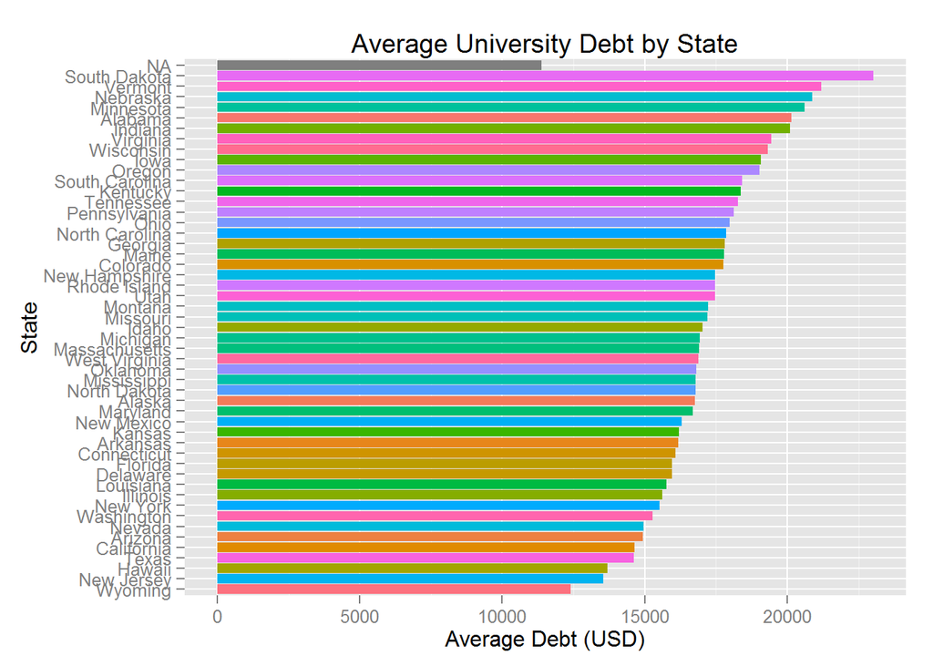

##### Analysis

From this data, we can see that, on average, South Dakota, Vermont and Nebraska are the most indebting states, while Wyoming, New Jersey, and Hawaii are the least. This does not support our hypothesis. This is interesting because this tells us that South Dakota and Nebraska, while more sparsely populated, have presumably a highest quality colleges/high density of affluent people. This indicates that they might be considered a destination college location. Conversely, this is interesting because Hawaii is one of the least indebting, perhaps hinging on the quality they provide/demographic they service, or some lower cost of living.

### Experiment 2:

##### Introduction

Our second experiment expands on the first. We want to know how the average percentage of students needing loans correlates with the average debt upon graduation, and analyze this correlation by regions. This is meaningful because it is a better indicator of the financial aid and cost of attendance at these states. For example, if a particular state has a relatively high average debt upon graduation compared to a relatively low percentage of students needing loans, this suggests that the cost of attendance in that state may be higher (increasing average debt upon graduation) but that more students would have financial aid at these schools (decreasing the percentage of students needing loans). Our hypothesis is that states in the Northeast and North Central regions will have higher debts coupled with lower percentage seeking loans, while states in the South and West will have the opposite.

##### Data and Visualizations

```r
source("../02 Data Wrangling/Workflow2.R", echo = TRUE)
```

```
##
## > df %>% select(PERCENT_FINLOAN, STATE, AVGGRADDEBT) %>%
## +     filter(AVGGRADDEBT != "null", PERCENT_FINLOAN != "null") %>%
## +     mutate(region = st .... [TRUNCATED]
## Source: local data frame [53 x 4]
##
##       region STATE state_avg_loan state_avg_debt
## 1  Northeast    CT      0.5606556       16073.15
## 2  Northeast    MA      0.5935417       16908.90
## 3  Northeast    ME      0.5528541       17787.01
## 4  Northeast    NH      0.6247706       17477.46
## 5  Northeast    NJ      0.5697029       13552.92
## 6  Northeast    NY      0.5789610       15514.25
## 7  Northeast    PA      0.6911099       18124.62
## 8  Northeast    RI      0.6047435       17469.02
## 9  Northeast    VT      0.6695565       21201.70
## 10     South    AL      0.6407638       20153.19
## ..       ...   ...            ...            ...
##
## > df %>% select(PERCENT_FINLOAN, STATE, AVGGRADDEBT) %>%
## +     filter(AVGGRADDEBT != "null", PERCENT_FINLOAN != "null") %>%
## +     mutate(region = st .... [TRUNCATED]
```

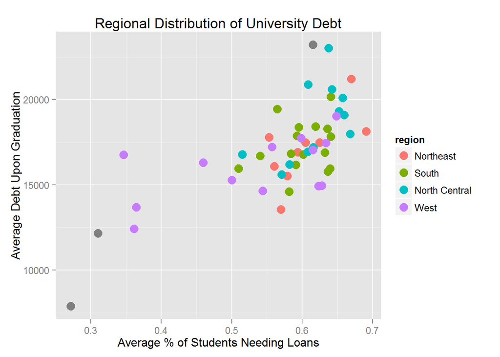

### Experiment 3: Examining success in high school and post-graduation, with race

##### Introduction

We wish to know how success in high school, and after college graduation, relates to race. We quantify success in high school as an average SAT score, and success after college graduation as initial income. Based on presumed US stereotypes of success by race, we would hypothesize that whites blanket and establish a heavy backgroup and average, Asians perform above average in both, while Blacks and Hispanics score low-medium average for both. Just to clarify - for this visualization, we calculated the majority race in each college and assigned that college’s data point the appropriate color.

##### Table and Visualizations

```r
source("../02 Data Wrangling/Workflow3.R", echo = TRUE)
```

```
##
## > df %>% select(PERCENT_WHITE, PERCENT_BLACK, PERCENT_HISPANIC,
## +     PERCENT_ASIAN, AVGSAT, GRADINCOME) %>% filter(PERCENT_WHITE !=
## +     "null", A .... [TRUNCATED]
## Source: local data frame [1,379 x 8]
##
##        PERCENT_WHITE      PERCENT_BLACK   PERCENT_HISPANIC
## 1  0.328000009059906 0.0421000011265278  0.225299999117851
## 2  0.384200006723404 0.0524999983608723  0.405800014734268
## 3  0.474500000476837 0.0125000001862645 0.0908999964594841
## 4  0.183799996972084  0.213799998164177  0.277500003576279
## 5  0.502099990844727 0.0359999984502792   0.26570001244545
## 6  0.610499978065491 0.0357999987900257  0.237900003790855
## 7  0.260699987411499 0.0626000016927719  0.483599990606308
## 8  0.160699993371964 0.0714000016450882  0.420399993658066
## 9   0.63129997253418 0.0377999991178513  0.110600002110004
## 10 0.489399999380112 0.0562999993562698  0.221000000834465
## ..               ...                ...                ...
## Variables not shown: PERCENT_ASIAN (fctr), AVGSAT (fctr), GRADINCOME
##   (fctr), majority_percent (dbl), majority (chr)
##
## > df %>% select(PERCENT_WHITE, PERCENT_BLACK, PERCENT_HISPANIC,
## +     PERCENT_ASIAN, AVGSAT, GRADINCOME) %>% filter(PERCENT_WHITE !=
## +     "null", A .... [TRUNCATED]
```

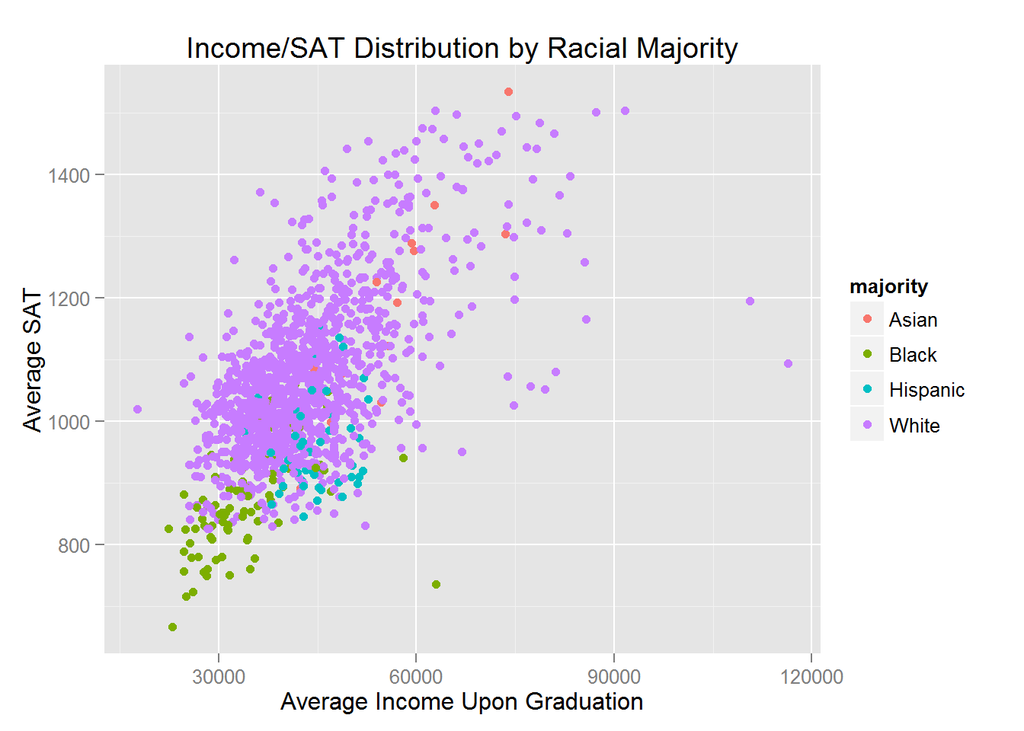

##### Conclusions

The data wrangling and visualization revealed that White demographic establishes the average, Asians perform above average in both, while Blacks and Hispanics score low-medium average for both. This supports our hypothesis. This is interesting because it demonstrates that there may be some truth behind the racial stereotypes in the US. At least, it indicates that there may be some grounding in a truth.